# team

Matthew Eisner

10/11/2020

```r
library(dplyr)
library(ggplot2)
library(tidyr)
library(readxl)
defense <- read_excel('./cyclonesFootball2019.xlsx', sheet='Defensive')
offense <- read_excel('./cyclonesFootball2019.xlsx', sheet='Offensive')
biography <- read_excel('./cyclonesFootball2019.xlsx', sheet='Biography')
```

## Part one: Cleaning data

Although the three Excel sheets are loaded into R, they are not useful before some cleaning. Manipulate the three imported data frames, so that in the cleaned dataset:

1. The player names and opponent names are factors.

```r
offense$Name <- as.factor(offense$Name)
offense$Opponent_Opponent <- as.factor(offense$Opponent_Opponent)

defense$Name <- as.factor(defense$Name)
defense$Opponent_Opponent <- as.factor(defense$Opponent_Opponent)

biography$Name <- as.factor(biography$Name)
```

2. All offensive and defensive statistics are numerical. The Weight column in biography is also numeric. (Optional: Learn to mutate multiple columns systematically using the `?across` function in `dplyr)

```r
offClean <- offense %>% mutate(across(where(is.character), as.numeric))
defClean <- defense %>% mutate(across(where(is.character), as.numeric))
bioClean <- biography %>% mutate(Weight = as.numeric(Weight))
```

3. Change the `Height` column in biography into numeric. (Hint: Use a unit that works well)

```r
bioClean <- bioClean %>%
  separate(Height, c('feet', 'inch'), sep='-') %>%
  mutate(feet = as.numeric(feet), inch = as.numeric(inch)) %>%
  mutate(Height_ft = feet + (inch/12)) %>%
  select(Name, Position, Height_ft, Weight, Class, Hometown, Highschool)
```

By cleaning the three data frames in R, at the end of this step you should have the following three clean data frames: `defClean`, `offClean`, and `bioClean`. Print the structures of these data frames.

```r
str(defClean)
```

```
## tibble [502 x 11] (S3: tbl_df/tbl/data.frame)
##  $ Name             : Factor w/ 43 levels "Akers, Landen",..: 40 40 40 40 40 40 40 40 40 40 ...
##  $ Opponent_Opponent: Factor w/ 13 levels "Baylor","Iowa",..: 12 2 11 1 8 13 10 7 6 9 ...
##  $ Tackles_Solo     : num [1:502] 4 4 3 4 3 1 7 3 6 5 ...
##  $ Tackles_ASST     : num [1:502] 4 7 5 2 2 1 1 2 1 5 ...
##  $ Tackles_TFL      : num [1:502] 0 0 0 0 1 0 0 0 1 1 ...
##  $ Tackles_Sack     : num [1:502] 0 0 0 0 0 0 0 0 0 1 ...
##  $ Turnover_FF      : num [1:502] 0 0 0 0 0 0 0 0 0 0 ...
##  $ Turnover_FR      : num [1:502] 0 0 0 0 0 0 0 0 0 0 ...
##  $ Turnover_INT     : num [1:502] 0 0 1 0 0 0 0 0 1 0 ...
##  $ Pass_QBH         : num [1:502] 1 0 0 0 0 0 0 0 1 0 ...
##  $ Pass_PB          : num [1:502] 1 2 0 0 0 1 0 0 0 0 ...
```

```r
str(offClean)
```

```
## tibble [195 x 12] (S3: tbl_df/tbl/data.frame)
##  $ Name             : Factor w/ 17 levels "Akers, Landen",..: 1 1 1 1 1 1 1 1 1 1 ...
##  $ Opponent_Opponent: Factor w/ 13 levels "Baylor","Iowa",..: 12 2 11 1 8 13 10 7 6 9 ...
##  $ Rushing_ATT      : num [1:195] 0 0 1 0 0 0 0 0 0 0 ...
##  $ Rushing_YDS      : num [1:195] 0 0 8 0 0 0 0 0 0 0 ...
##  $ Rushing_TD       : num [1:195] 0 0 0 0 0 0 0 0 0 0 ...
##  $ Receiving_REC    : num [1:195] 1 0 0 0 1 0 0 4 0 1 ...
##  $ Receiving_YDS    : num [1:195] 21 0 0 0 32 0 0 39 0 7 ...
##  $ Receiving_TD     : num [1:195] 0 0 0 0 0 0 0 0 0 0 ...
##  $ Passing_CMP-ATT  : num [1:195] NA NA NA NA NA NA NA NA NA NA ...
##  $ Passing_YDS      : num [1:195] NA NA NA NA NA NA NA NA NA NA ...
##  $ Passing_TD       : num [1:195] NA NA NA NA NA NA NA NA NA NA ...
##  $ Passing_INT      : num [1:195] NA NA NA NA NA NA NA NA NA NA ...
```

```r
str(bioClean)
```

```
## tibble [105 x 7] (S3: tbl_df/tbl/data.frame)
##  $ Name      : Factor w/ 105 levels "Akers, Landen",..: 1 2 3 4 5 6 7 8 9 10 ...
##  $ Position  : chr [1:105] "Wide Receiver" "Tight End" "Wide Receiver" "Placekicker" ...
##  $ Height_ft : num [1:105] 6 6.58 6.42 6 6 ...
##  $ Weight    : num [1:105] 188 245 204 195 190 235 255 285 300 215 ...
##  $ Class     : chr [1:105] "Redshirt Senior" "Redshirt Senior" "Redshirt Freshman" "Redshirt Senior" ...
##  $ Hometown  : chr [1:105] "Cedar Rapids, Iowa" "Nixa, Mo." "Seffner, Fla." "Naperville, Ill." ...
##  $ Highschool: chr [1:105] "Washington" "Nixa" "Armwood" "Central" ...
```

## Part two: Tidying

For the following questions, work on the cleaned data frames `defClean`, `offClean`, and `bioClean`.

1. Reformat the `defClean` data frame into a tidy format using `pivot_longer`. The type of statistic (Tackles_Solo, Tackles_ASST, etc) is added as a new key column named `stat`.

```r
defClean <- defClean %>% pivot_longer(Tackles_Solo:Pass_PB, names_to='stat', values_to='count')
```

2. Compare the distributions of the defensive statistics. What defensive skills are rare?

The following defensive skills are rare: Turnover_INT, Turnover_FR, Turnover_FF, Tackles_Sack, Tackles_TFL, Pass_PB, and Pass_QBH. These skills often do not happen in a game but if they do, usually only once.

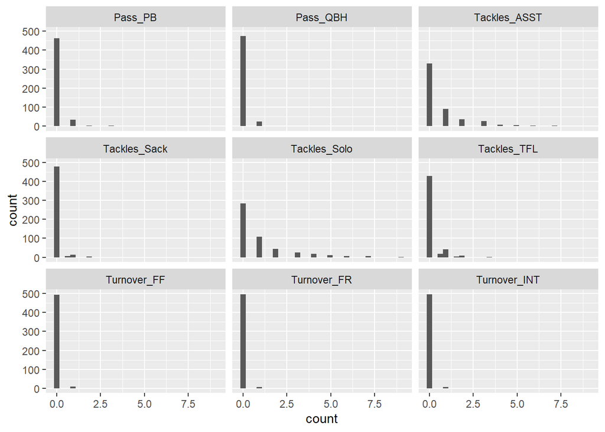

```r
defClean %>% ggplot(aes(x=count)) + geom_histogram() + facet_wrap(~stat)
```

3. Did ISU have better defense against Iowa or Notre Dame? Answer this question by creating a scatterplot with x- and y-axes being the number of solo tackles (of each player). A large number of solo tackles is an indicator of good defense.

The defense played better against Notre Dame. This is because there were significantly more solo tackles by defensive players than in the Iowa game. For example, Mike Rose had 5 solo tackles in the Notre Dame game and only 2 solo tackles in the Iowa game.

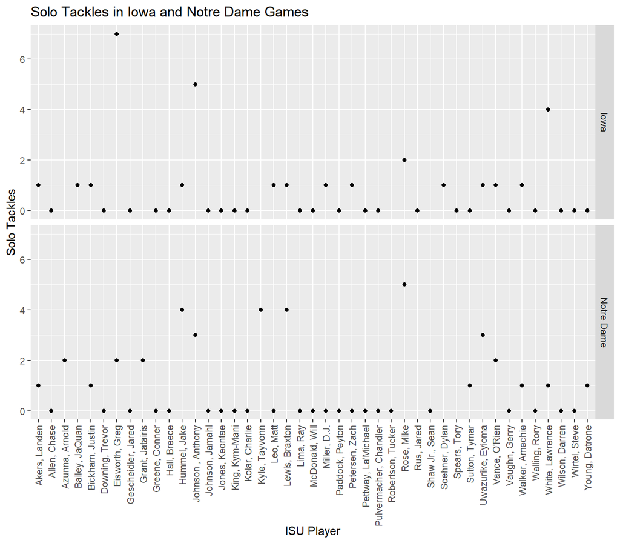

```r
defClean %>%
  filter(stat=='Tackles_Solo' & Opponent_Opponent %in% c('Iowa', 'Notre Dame')) %>%
  ggplot(aes(x=Name, y=count)) + geom_point() +
  theme(axis.text.x = element_text(angle=90, vjust=0.5, hjust=1)) +
  ggtitle('Solo Tackles in Iowa and Notre Dame Games') +
  xlab('ISU Player') + ylab('Solo Tackles') +
  facet_grid(rows=vars(Opponent_Opponent))
```

Now turn our attention to the player biography.

4. Separate the `Hometown` column into two columns, namely the city and the state. Print the first few rows of these two columns. (Hint: look at the `sep=` argument of `separate`)

```r
bioClean <- bioClean %>% separate(Hometown, c('City', 'State'), sep=', ')
bioClean %>%
  select(City, State) %>%
  head()
```

```
## # A tibble: 6 x 2
##   City          State
##   <chr>         <chr>
## 1 Cedar Rapids  Iowa
## 2 Nixa          Mo.
## 3 Seffner       Fla.
## 4 Naperville    Ill.
## 5 Grand Prairie Texas
## 6 Clarksdale    Miss.
```

5. How many players are there from each state?

```r
bioClean %>%
  group_by(State) %>%
  summarize(Number.of.Players=n())
```

```
## # A tibble: 19 x 2
##    State     Number.of.Players
##    <chr>                 <int>
##  1 Ariz.                     4
##  2 Ark.                      1
##  3 Australia                 1
##  4 Calif.                    3
##  5 Fla.                     10
##  6 Ga.                       4
##  7 Ill.                      5
##  8 Iowa                     35
##  9 Kan.                      3
## 10 Mich.                     4
## 11 Minn.                     4
## 12 Miss.                     1
## 13 Mo.                       6
## 14 Ohio                      7
## 15 Okla.                     2
## 16 Pa.                       1
## 17 S.D.                      2
## 18 Texas                     6
## 19 Wis.                      6
```

## Part three: Joining data frames

1. Find which states do the ISU defensive and offensive players come from. Create an appropriate summary.

```r
offClean %>%
  left_join(bioClean, by='Name') %>%
  group_by(Name, State) %>%
  summarize()
```

```
## # A tibble: 17 x 2
## # Groups:   Name [17]
##    Name                State
##    <fct>               <chr>
##  1 Akers, Landen       Iowa
##  2 Allen, Chase        Mo.
##  3 Brock, Jirehl       Ill.
##  4 Croney Jr., Sheldon <NA>
##  5 Hall, Breece        Kan.
##  6 Jones, Deshaunte    <NA>
##  7 Kolar, Charlie      Okla.
##  8 Lang, Johnnie       Fla.
##  9 Milton, Tarique     Fla.
## 10 Mitchell, Re-al     <NA>
## 11 Nwangwu, Kene       Texas
## 12 Pettway, La'Michael <NA>
## 13 Purdy, Brock        Ariz.
## 14 Scates, Joe         Ohio
## 15 Shaw Jr., Sean      Okla.
## 16 Soehner, Dylan      Ark.
## 17 Wilson, Darren      Ga.
```

```r
defClean %>%
  left_join(bioClean, by='Name') %>%
  group_by(Name, State) %>%
  summarize()
```

```
## # A tibble: 43 x 2
## # Groups:   Name [43]
##    Name               State
##    <fct>              <chr>
##  1 Akers, Landen      Iowa
##  2 Allen, Chase       Mo.
##  3 Azunna, Arnold     Texas
##  4 Bailey, JaQuan     Fla.
##  5 Bickham, Justin    <NA>
##  6 Downing, Trevor    Iowa
##  7 Eisworth, Greg     Texas
##  8 Gescheidler, Jared <NA>
##  9 Grant, Jatairis    Ohio
## 10 Greene, Conner     <NA>
## # ... with 33 more rows
```

2. How does the performance of quarterback Brock Purdy relate to the performance of the ISU team?

To answer this question, I calculated the “fantasy score” for each player, each game. This was done using standard weightings of a typical PPR (point per reception) NFL fantasy league. In short, the higher the fantasy point value for a player, the better they performed in the football game. I chose to compare these fantasy scores from four games over the 2019 season, one where Brock Purdy did poorly, one where Brock Purdy did very well, and two in-between games for Brock Purdy. For readability, I chose to analyze Brock Purdy, Breece Hall, and the top five receivers on the depth chart from 2019 (wide receivers and tight ends will be together considered as ‘receivers’)

In the Notre Dame and Oklahoma State games where Purdy did not do very well with less than 20 points, Breece Hall was the highest scoring player on the offense. In the Texas game, Purdy had a fair showing with just above 20 points and Breece Hall did not do as well, scoring the fifth highest of selected players. In Purdy’s best game, against ULM, he scored over 50 points with large showings from his top receivers as well. Breece Hall scored much less than most other players on offense this game. From this, we learn that the better Brock Purdy does, the better his recievers do. The worse Brock Purdy does, the worse his recievers eperform but the better Breece Hall does. This makes sense because if the passing game is very successful, the team will continue to pass. However, if Brock Purdy is not passing well, the running game with Breece Hall is going to be utilized more.

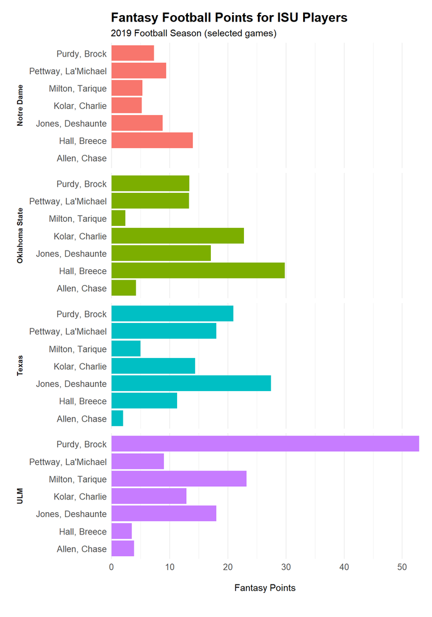

```r
fantasy <- offClean %>%
  mutate_if(is.numeric, ~replace(., is.na(.), 0)) %>%
  mutate(fantasy_points = Rushing_YDS*0.1 + Rushing_TD*6 +
           Receiving_REC + Receiving_YDS*0.1 + Receiving_TD*6 +
           Passing_YDS*0.04 + Passing_TD*4 - Passing_INT*2)

fantasy %>%
  filter(Opponent_Opponent %in% c('ULM','Notre Dame', 'Texas', 'Oklahoma State')) %>%
  filter(Name %in% c('Purdy, Brock', "Pettway, La'Michael", 'Hall, Breece', 'Kolar, Charlie', 'Jones, Deshaunte',
                     'Milton, Tarique', 'Allen, Chase')) %>%
  ggplot(aes(x=Name, weight=fantasy_points, fill=Opponent_Opponent)) +
  geom_bar() +
  scale_y_continuous(expand = c(0, 0.1)) +
  coord_flip() +
  facet_grid(rows = vars(Opponent_Opponent), scales = "free_y", switch = "y", space = "free_y") +
  labs(
    title = "Fantasy Football Points for ISU Players",
    subtitle = "2019 Football Season (selected games)",
    y = "Fantasy Points") +
  theme_minimal(base_family = "Roboto Condensed") +
  theme(
    plot.margin = margin(0.5, 0.5, 0.5, 0.5, unit = "cm"),
    plot.title = element_text(size = 15, face = "bold"),
    strip.text.y = element_text(angle = 270, face = "bold"),
    strip.placement = "outside",
    axis.title.x = element_text(margin = margin(t = 0.5, b = 0.5, unit = "cm")),
    axis.title.y = element_blank(),
    axis.text = element_text(size = 10),
    legend.position = "none",
    panel.grid.major.y = element_blank())
```

3. Which ISU player(s) made big progress over the last year? Compare the 2019 and the 2018 data here.

The following player made big progress over the last year: Chase Allen, Deshaunte Jones, Charlie Kolar, Johnnie Lang, and Tarique Milton. All of these players both had an increase in the average amount of fantasy points they scored per game (mean.ppg in the table below) and totaled more fantasy points over the season (total.pts in the table below). The biggest improvement was seen in Charlie Kolar, who had more than triple the total fantasy points in 2019 than he had in 2018 and over tripled his average fantasy score per game.

```r
defense2018 <- read_excel('./cyclonesFootball2018.xlsx', sheet='Defensive')
offense2018 <- read_excel('./cyclonesFootball2018.xlsx', sheet='Offensive')

offense2018$Name <- as.factor(offense2018$Name)
offense2018$Opponent_Opponent <- as.factor(offense2018$Opponent_Opponent)
defense2018$Name <- as.factor(defense2018$Name)
defense2018$Opponent_Opponent <- as.factor(defense2018$Opponent_Opponent)
offense2018 <- offense2018 %>% mutate(across(where(is.character), as.numeric))
defense2018 <- defense2018 %>% mutate(across(where(is.character), as.numeric))

fantasy2018 <- offense2018 %>%
  mutate_if(is.numeric, ~replace(., is.na(.), 0)) %>%
  mutate(fantasy_points_2018 = Rushing_YDS*0.1 + Rushing_TD*6 +
           Receiving_REC + Receiving_YDS*0.1 + Receiving_TD*6 +
           Passing_YDS*0.04 + Passing_TD*4 - Passing_INT*2)

fantasy %>%
  select(-Rushing_YDS, -Rushing_TD, -Receiving_REC, -Receiving_YDS,
         -Receiving_TD, -Passing_YDS, -Passing_TD, -Passing_INT,
         -Rushing_ATT, -`Passing_CMP-ATT`) %>%
  inner_join(fantasy2018 %>% select(Name, Opponent_Opponent, fantasy_points_2018),
             by=c('Name', 'Opponent_Opponent')) %>%
  group_by(Name) %>%
  summarize(mean.ppg.2018=mean(fantasy_points_2018), mean.ppg.2019=mean(fantasy_points),
            total.pts.2018=sum(fantasy_points_2018), total.pts.2019=sum(fantasy_points))
```

```
## # A tibble: 8 x 5
##   Name             mean.ppg.2018 mean.ppg.2019 total.pts.2018 total.pts.2019
##   <fct>                    <dbl>         <dbl>          <dbl>          <dbl>
## 1 Akers, Landen             2.3           1.68           23             16.8
## 2 Allen, Chase              2.1           4.63           12.6           27.8
## 3 Jones, Deshaunte          7.84         12.8            78.4          128.
## 4 Kolar, Charlie            4.14         13.6            41.4          136.
## 5 Lang, Johnnie             1.7           5.19           17             51.9
## 6 Milton, Tarique           7.18          9.29           71.8           92.9
## 7 Nwangwu, Kene             1.61          0.81           16.1            8.1
## 8 Purdy, Brock             23.0          20.4           161.           143.
```